# Coastal air temperature in the Gulf of California

Coastal air temperature is the temperature felt on shore, where intertidal animals, mangroves, nesting sea turtles, and marine birds live. The shore record bends, so it is summarized as a departure from a reference climate rather than as a straight line.

The temperature is the daily mean of Daymet maximum and minimum air temperature. Daymet Version 4 R1 places those values on a 1 km grid for North America, including the Mexican coast of the Gulf, for 1980 through 2025. The source is Thornton, M. M., R. Shrestha, Y. Wei, P. E. Thornton, S-C. Kao, and B. E. Wilson (2022), Daymet: Daily Surface Weather Data on a 1-km Grid for North America, Version 4 R1, ORNL DAAC, https://doi.org/10.3334/ORNLDAAC/2129. Each file below is the public single-pixel extract for one coastal cell.

The cells are the land within 1 km of the Gulf shoreline, inside the OHI land regions. One kilometer is the width of a Daymet cell, so the average stays on the shore instead of mixing the beach with the desert behind it.

The reference climate is the mean of 1980–2000. Each later year is the difference from that mean. Because single years jump around, each plotted value is then the mean of that year and the four years before it. The last value, for 2025, is the mean of 2021–2025 minus the 1980–2000 mean. The same summary is then repeated for the three warmest months in the Gulf, chosen from the 1980–2000 climate and held fixed.

The saved pressure divides that five-year anomaly by 3°C. A departure of 3°C scores 1. A larger departure stays at 1, and a cooling stays at 0. Each region keeps a pressure for every year from 2000 through 2025. The value dated 2025 is the mean of 2021–2025, not the single year 2025.

Raw cell files are written to `/home/shares/ohi/OHI_GOC/_raw_data/Temp_daymet`. The shoreline sample is written to `/home/shares/ohi/OHI_GOC/goal_prep/pressures/air_temp`. The pressure tables, the summary spreadsheet, and the 2025 rasters are written to `_pressures/prs_air_temp/output`.

```r
library(sf)
library(terra)
library(tidyverse)
library(knitr)
library(writexl)

# Area calculations below use the region projection, in meters.
sf_use_s2(FALSE)
```

```
## Spherical geometry (s2) switched off
```

```r
knitr::opts_chunk$set(fig.width = 8, fig.height = 6, message = FALSE, warning = FALSE)

rgn_path <- "/home/shares/ohi/OHI_GOC/spatial/OHI_regions/goc_ohi_rgns.shp"
coast_path <- "/home/shares/ohi/OHI_GOC/spatial/OHI_regions/goc_coastline.gpkg"
raw_dir <- "/home/shares/ohi/OHI_GOC/_raw_data/Temp_daymet"
int_dir <- "/home/shares/ohi/OHI_GOC/goal_prep/pressures/air_temp"
out_dir <- "/home/frazier/ohi_goc_prep/_pressures/prs_air_temp/output"
dir.create(raw_dir, showWarnings = FALSE, recursive = TRUE)
dir.create(int_dir, showWarnings = FALSE, recursive = TRUE)
dir.create(out_dir, showWarnings = FALSE, recursive = TRUE)

# A 3°C departure from 1980–2000 is a pressure of 1.
reference_rise_c <- 3

# How far inland a cell may sit and still count as the coast.
shore_m <- 1000
```

## 1. The coastal cells

Each OHI region has a land polygon and a marine polygon. Air temperature is taken from the land polygon. The shoreline is sampled every kilometer, and each sample is moved a short distance inland so it lands in a Daymet land cell rather than in the water. Samples that miss the land regions are dropped. A circle that touches two regions keeps the piece with the larger area.

```r
sites_path <- file.path(int_dir, "coastal_cells.gpkg")

if (file.exists(sites_path)) {
  sites <- st_read(sites_path, quiet = TRUE)
} else {
  land <- st_read(rgn_path, quiet = TRUE) %>%
    st_make_valid() %>%
    filter(location == "land")

  # The coastline is already stored in the same projection as the regions.
  coast <- st_read(coast_path, quiet = TRUE) %>%
    st_transform(st_crs(land)) %>%
    st_cast("LINESTRING")

  # A vertex at least every kilometer. Shared corners are kept once.
  samples <- st_segmentize(st_union(st_geometry(coast)), dfMaxLength = shore_m) %>%
    st_cast("POINT") %>%
    st_sf()
  xy <- st_coordinates(samples)
  samples <- samples %>%
    mutate(x = round(xy[, 1]), y = round(xy[, 2])) %>%
    distinct(x, y, .keep_all = TRUE) %>%
    mutate(sample_id = seq_len(n())) %>%
    select(sample_id)

  # A point that starts on the shoreline is moved inland by taking the
  # centroid of its overlap with the land region.
  pieces <- st_buffer(samples, shore_m / 2) %>%
    st_intersection(land) %>%
    mutate(piece_km2 = as.numeric(st_area(geometry)) / 1e6) %>%
    group_by(sample_id) %>%
    slice_max(piece_km2, n = 1, with_ties = FALSE) %>%
    ungroup()

  sites <- st_centroid(pieces) %>%
    st_transform(4326) %>%
    mutate(
      lon = st_coordinates(geometry)[, 1],
      lat = st_coordinates(geometry)[, 2]
    ) %>%
    select(sample_id, rgn_id, estado, ecorgn, lon, lat)

  st_write(sites, sites_path, quiet = TRUE)
}

sites %>%
  st_drop_geometry() %>%
  count(rgn_id, estado, ecorgn, name = "n_cells") %>%
  kable(
    col.names = c("Region", "State", "Ecoregion", "Coastal cells"),
    caption = "Shoreline cells within 1 km of the coast, one per kilometer of shoreline"
  )
```

Shoreline cells within 1 km of the coast, one per kilometer of shoreline

| Region | State | Ecoregion | Coastal cells |
| --- | --- | --- | --- |
| Region_1 | Baja_California | Upper_Gulf | 105 |
| Region_2 | Baja_California | Midriff_Region | 990 |
| Region_3 | Baja_California_Sur | Central_Gulf | 519 |
| Region_4 | Baja_California_Sur | Southern_Gulf | 1416 |
| Region_5 | Sonora | Upper_Gulf | 194 |
| Region_6 | Sonora | Midriff_Region | 813 |
| Region_7 | Sonora | Central_Gulf | 724 |
| Region_8 | Sinaloa | Southern_Gulf | 1254 |
| Region_9 | Nayarit | Southern_Gulf | 524 |

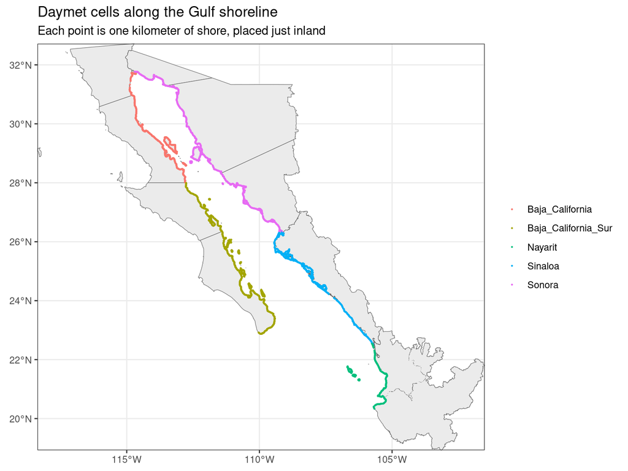

```r
land_outline <- st_read(rgn_path, quiet = TRUE) %>%
  st_make_valid() %>%
  filter(location == "land") %>%
  st_transform(4326)

ggplot() +
  geom_sf(data = land_outline, fill = "grey92", color = "grey40", linewidth = 0.2) +
  geom_sf(data = sites, aes(color = estado), size = 0.15) +
  coord_sf(expand = FALSE) +
  labs(
    title = "Daymet cells along the Gulf shoreline",
    subtitle = "Each point is one kilometer of shore, placed just inland",
    color = NULL
  ) +
  theme_bw()
```

## 2. Download the Daymet record

Each cell is requested from the Daymet single-pixel service for 1 January 1980 through 31 December 2025. The service returns the 1 km cell that contains the point. A cell that falls in the water comes back as a short error message and is left out. Files already on disk are kept, so a second knit continues where the first one stopped.

```r
# Read the first line and decide whether this file is a real Daymet table.
daymet_ok <- function(path) {
  if (!file.exists(path) || file.info(path)$size < 1000) return(FALSE)
  !startsWith(readLines(path, n = 1, warn = FALSE), "{")
}

download_one <- function(sample_id, lat, lon) {
  dest <- file.path(raw_dir, sprintf("daymet_%05d.csv", sample_id))
  if (daymet_ok(dest)) return(dest)
  url <- sprintf(
    "https://daymet.ornl.gov/single-pixel/api/data?lat=%s&lon=%s&vars=tmax,tmin&start=1980-01-01&end=2025-12-31",
    format(lat, scientific = FALSE, trim = TRUE),
    format(lon, scientific = FALSE, trim = TRUE)
  )
  status <- system2(
    "curl",
    c("-s", "-L", "--retry", "2", "--max-time", "120", "-o", dest, shQuote(url))
  )
  if (status != 0 || !daymet_ok(dest)) {
    if (file.exists(dest)) file.remove(dest)
    return(NA_character_)
  }
  dest
}

# A handful of requests at once. Forked workers only run curl, then return.
paths <- parallel::mcmapply(
  download_one,
  sites$sample_id,
  sites$lat,
  sites$lon,
  mc.cores = 8,
  USE.NAMES = FALSE
)

sites <- sites %>%
  mutate(path = paths) %>%
  filter(!is.na(path))

cat(
  "Cells with a temperature record:", nrow(sites),
  "of", length(paths), "shoreline samples\n"
)
```

```
## Cells with a temperature record: 6427 of 6539 shoreline samples
```

## 3. Daily values to a yearly mean

The file header carries the Daymet cell coordinate. Two shoreline samples can fall in the same 1 km cell where the shore bends; those duplicates are removed so the bend is not counted twice. The value for a day is the average of the maximum and the minimum. The value for a year is the average of the days, with each day weighted equally.

```r
read_cell <- function(path, sample_id) {
  header <- readLines(path, n = 2, warn = FALSE)
  xy <- strsplit(sub(".*: ", "", header[2]), " ", fixed = TRUE)[[1]]
  daily <- read_csv(path, skip = 6, show_col_types = FALSE)
  names(daily) <- c("year", "yday", "tmax", "tmin")
  daily %>%
    mutate(
      sample_id = sample_id,
      cell_x = round(as.numeric(xy[1])),
      cell_y = round(as.numeric(xy[2])),
      tmean = (tmax + tmin) / 2
    )
}

# Read in batches so the daily tables do not all sit in memory at once.
batch_size <- 400
batch_id <- ceiling(seq_len(nrow(sites)) / batch_size)
annual_cell <- vector("list", max(batch_id))
month_cell <- vector("list", max(batch_id))
year_month <- vector("list", max(batch_id))

for (b in sort(unique(batch_id))) {
  keep <- which(batch_id == b)
  daily <- map2(sites$path[keep], sites$sample_id[keep], read_cell) %>%
    list_rbind()
  # One row per Daymet cell. The first sample that landed in the cell is kept.
  daily <- daily %>%
    group_by(cell_x, cell_y) %>%
    filter(sample_id == min(sample_id)) %>%
    ungroup() %>%
    mutate(month = as.integer(format(as.Date(sprintf("%d-%03d", year, yday), "%Y-%j"), "%m")))
  annual_cell[[b]] <- daily %>%
    group_by(sample_id, cell_x, cell_y, year) %>%
    summarise(tmean = mean(tmean), .groups = "drop")
  month_cell[[b]] <- daily %>%
    group_by(sample_id, month) %>%
    summarise(tmean = mean(tmean), .groups = "drop")
  # Year and month together, so the warm-season summary can use the same days.
  year_month[[b]] <- daily %>%
    group_by(sample_id, year, month) %>%
    summarise(tmean = mean(tmean), .groups = "drop")
}

annual_cell <- list_rbind(annual_cell)
month_cell <- list_rbind(month_cell)
year_month <- list_rbind(year_month)

# The same Daymet cell can appear in more than one batch where the shore bends.
annual_cell <- annual_cell %>%
  group_by(cell_x, cell_y) %>%
  filter(sample_id == min(sample_id)) %>%
  ungroup()

month_cell <- month_cell %>%
  filter(sample_id %in% unique(annual_cell$sample_id))

year_month <- year_month %>%
  filter(sample_id %in% unique(annual_cell$sample_id))

# Attach the region after collapsing duplicate cells.
annual_cell <- annual_cell %>%
  inner_join(st_drop_geometry(sites), by = "sample_id")

month_region <- month_cell %>%
  inner_join(st_drop_geometry(sites) %>% select(sample_id, rgn_id, estado), by = "sample_id") %>%
  group_by(rgn_id, estado, month) %>%
  summarise(tmean = mean(tmean), .groups = "drop")

cat("Unique Daymet cells:", n_distinct(paste(annual_cell$cell_x, annual_cell$cell_y)), "\n")
```

```
## Unique Daymet cells: 6426
```

```r
cat("Years:", min(annual_cell$year), "through", max(annual_cell$year), "\n")
```

```
## Years: 1980 through 2025
```

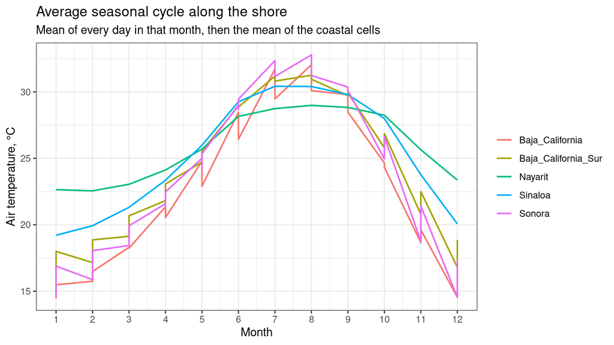

```r
ggplot(month_region, aes(month, tmean, color = estado)) +
  geom_line(linewidth = 0.7) +
  scale_x_continuous(breaks = 1:12) +
  labs(
    title = "Average seasonal cycle along the shore",
    subtitle = "Mean of every day in that month, then the mean of the coastal cells",
    x = "Month",
    y = "Air temperature, °C",
    color = NULL
  ) +
  theme_bw()
```

The seasonal cycle is the check that the cells are on land in this climate. Summers are hot and winters are mild, and the upper Gulf has the wider swing.

```r
annual_region <- annual_cell %>%
  group_by(rgn_id, estado, ecorgn, year) %>%
  summarise(
    tmean = mean(tmean),
    n_cells = n(),
    .groups = "drop"
  ) %>%
  arrange(rgn_id, year)

kable(
  annual_region %>% filter(year %in% c(1980, 2000, 2025)),
  digits = 2,
  col.names = c("Region", "State", "Ecoregion", "Year", "Mean air temperature, °C", "Cells"),
  caption = "Yearly mean coastal air temperature in three years of the record"
)
```

Yearly mean coastal air temperature in three years of the record

| Region | State | Ecoregion | Year | Mean air temperature, °C | Cells |
| --- | --- | --- | --- | --- | --- |
| Region_1 | Baja_California | Upper_Gulf | 1980 | 21.46 | 104 |
| Region_1 | Baja_California | Upper_Gulf | 2000 | 23.43 | 104 |
| Region_1 | Baja_California | Upper_Gulf | 2025 | 23.79 | 104 |
| Region_2 | Baja_California | Midriff_Region | 1980 | 21.19 | 990 |
| Region_2 | Baja_California | Midriff_Region | 2000 | 21.08 | 990 |
| Region_2 | Baja_California | Midriff_Region | 2025 | 22.99 | 990 |
| Region_3 | Baja_California_Sur | Central_Gulf | 1980 | 23.80 | 513 |
| Region_3 | Baja_California_Sur | Central_Gulf | 2000 | 22.80 | 513 |
| Region_3 | Baja_California_Sur | Central_Gulf | 2025 | 22.90 | 513 |
| Region_4 | Baja_California_Sur | Southern_Gulf | 1980 | 24.00 | 1403 |
| Region_4 | Baja_California_Sur | Southern_Gulf | 2000 | 24.29 | 1403 |
| Region_4 | Baja_California_Sur | Southern_Gulf | 2025 | 25.10 | 1403 |
| Region_5 | Sonora | Upper_Gulf | 1980 | 22.46 | 188 |
| Region_5 | Sonora | Upper_Gulf | 2000 | 23.34 | 188 |
| Region_5 | Sonora | Upper_Gulf | 2025 | 25.04 | 188 |
| Region_6 | Sonora | Midriff_Region | 1980 | 21.95 | 804 |
| Region_6 | Sonora | Midriff_Region | 2000 | 22.71 | 804 |
| Region_6 | Sonora | Midriff_Region | 2025 | 23.04 | 804 |
| Region_7 | Sonora | Central_Gulf | 1980 | 23.68 | 694 |
| Region_7 | Sonora | Central_Gulf | 2000 | 24.21 | 694 |
| Region_7 | Sonora | Central_Gulf | 2025 | 24.45 | 694 |
| Region_8 | Sinaloa | Southern_Gulf | 1980 | 25.31 | 1213 |
| Region_8 | Sinaloa | Southern_Gulf | 2000 | 24.68 | 1213 |
| Region_8 | Sinaloa | Southern_Gulf | 2025 | 25.78 | 1213 |
| Region_9 | Nayarit | Southern_Gulf | 1980 | 27.27 | 517 |
| Region_9 | Nayarit | Southern_Gulf | 2000 | 26.19 | 517 |
| Region_9 | Nayarit | Southern_Gulf | 2025 | 26.49 | 517 |

## 4. Departure from 1980–2000

The reference for a region is the mean of its yearly values from 1980 through 2000. The anomaly in any year, including those reference years, is the yearly mean minus that reference. A warm year is positive.

The five-year value for a year is the mean of that year’s anomaly and the anomalies from the four years before it. The window is trailing, so 2025 uses 2021–2025 and can be updated without waiting for later years. The first complete window is 1984. The years 1980–1983 stay blank.

```r
# Mean of this year and the four years before it. The first four years of
# a complete series are left missing.
trailing_five <- function(x) {
  (x + lag(x, 1) + lag(x, 2) + lag(x, 3) + lag(x, 4)) / 5
}

anomaly <- annual_region %>%
  group_by(rgn_id, estado, ecorgn) %>%
  arrange(year, .by_group = TRUE) %>%
  mutate(
    reference_c = mean(tmean[year >= 1980 & year <= 2000]),
    anomaly_c = tmean - reference_c,
    roll5_c = trailing_five(anomaly_c)
  ) %>%
  ungroup()

latest <- anomaly %>%
  filter(year == 2025) %>%
  arrange(rgn_id)

kable(
  latest %>%
    transmute(rgn_id, estado, ecorgn, reference_c, anomaly_c, roll5_c),
  digits = 2,
  col.names = c(
    "Region", "State", "Ecoregion",
    "1980–2000 mean, °C", "2025 anomaly, °C", "2021–2025 anomaly, °C"
  ),
  caption = "The 2021–2025 column is the trailing five-year anomaly. It is the summary used for the shore."
)
```

The 2021–2025 column is the trailing five-year anomaly. It is the summary used for the shore.

| Region | State | Ecoregion | 1980–2000 mean, °C | 2025 anomaly, °C | 2021–2025 anomaly, °C |
| --- | --- | --- | --- | --- | --- |
| Region_1 | Baja_California | Upper_Gulf | 22.59 | 1.20 | 0.45 |
| Region_2 | Baja_California | Midriff_Region | 21.26 | 1.73 | 2.87 |
| Region_3 | Baja_California_Sur | Central_Gulf | 23.36 | -0.46 | 1.10 |
| Region_4 | Baja_California_Sur | Southern_Gulf | 24.19 | 0.90 | 1.54 |
| Region_5 | Sonora | Upper_Gulf | 22.73 | 2.31 | 1.55 |
| Region_6 | Sonora | Midriff_Region | 22.32 | 0.72 | 1.54 |
| Region_7 | Sonora | Central_Gulf | 23.61 | 0.85 | 1.47 |
| Region_8 | Sinaloa | Southern_Gulf | 24.86 | 0.92 | 1.09 |
| Region_9 | Nayarit | Southern_Gulf | 25.09 | 1.40 | 1.61 |

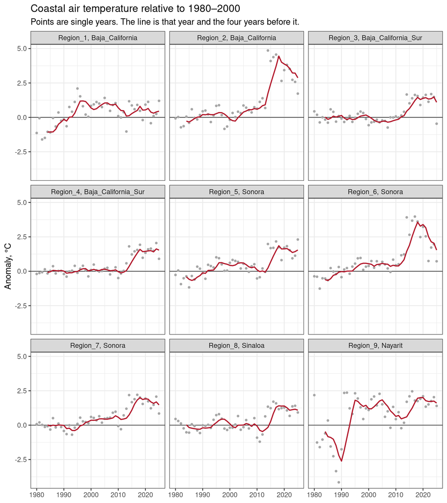

```r
ggplot(anomaly, aes(year)) +
  geom_hline(yintercept = 0, linewidth = 0.3) +
  geom_point(aes(y = anomaly_c), color = "grey65", size = 0.9) +
  geom_line(aes(y = roll5_c), color = "#b2182b", linewidth = 0.7) +
  facet_wrap(vars(paste(rgn_id, estado, sep = ", ")), ncol = 3) +
  labs(
    title = "Coastal air temperature relative to 1980–2000",
    subtitle = "Points are single years. The line is that year and the four years before it.",
    x = NULL,
    y = "Anomaly, °C"
  ) +
  theme_bw()
```

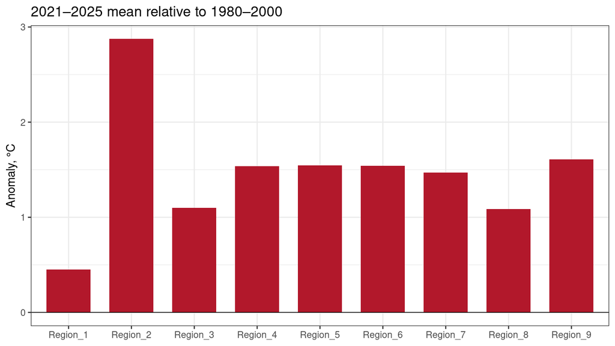

```r
ggplot(latest, aes(rgn_id, roll5_c, fill = roll5_c > 0)) +
  geom_col(width = 0.7) +
  geom_hline(yintercept = 0, linewidth = 0.3) +
  scale_fill_manual(values = c("TRUE" = "#b2182b", "FALSE" = "#2166ac"), guide = "none") +
  labs(
    title = "2021–2025 mean relative to 1980–2000",
    x = NULL,
    y = "Anomaly, °C"
  ) +
  theme_bw()
```

```r
# The same two means, taken inside each coastal cell, so the map shows
# whether the whole shore of a region moved together.
cell_anomaly <- annual_cell %>%
  group_by(sample_id) %>%
  summarise(
    anomaly_2025 = mean(tmean[year >= 2021 & year <= 2025]) -
      mean(tmean[year >= 1980 & year <= 2000]),
    .groups = "drop"
  )

cell_sf <- sites %>%
  select(sample_id) %>%
  inner_join(cell_anomaly, by = "sample_id")
```

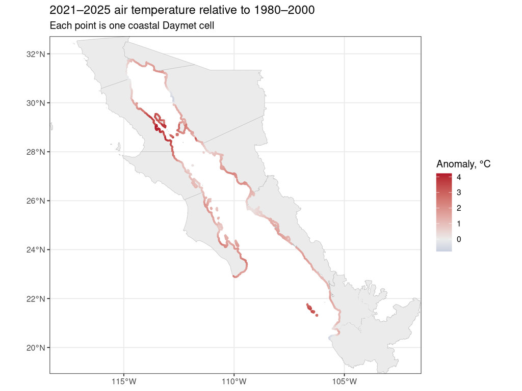

```r
ggplot() +
  geom_sf(data = land_outline, fill = "grey92", color = "grey70", linewidth = 0.15) +
  geom_sf(data = cell_sf, aes(color = anomaly_2025), size = 0.25) +
  scale_color_gradient2(
    low = "#2166ac",
    mid = "grey92",
    high = "#b2182b",
    midpoint = 0,
    name = "Anomaly, °C"
  ) +
  coord_sf(expand = FALSE) +
  labs(
    title = "2021–2025 air temperature relative to 1980–2000",
    subtitle = "Each point is one coastal Daymet cell"
  ) +
  theme_bw()
```

The cell map is the spatial check. A shore drawn in one color moved together. A shore with both colors has a recent climate that depends on where you stand.

## 5. The three warmest months

The three months are chosen once, from the mean of every coastal cell in 1980–2000, and then used for every region and every later year. A warmer year does not get to pick a different season. Within those months the summary is the same one used for the full year: the 1980–2000 mean, the anomaly, and the trailing five-year average.

```r
# One Gulf-wide season, not a different trio in each region.
warm_months <- year_month %>%
  filter(year >= 1980, year <= 2000) %>%
  group_by(month) %>%
  summarise(tmean = mean(tmean), .groups = "drop") %>%
  slice_max(tmean, n = 3) %>%
  arrange(month)

kable(
  warm_months,
  digits = 2,
  col.names = c("Month", "1980–2000 coastal mean, °C"),
  caption = "The three warmest months along the Gulf shore in the reference years"
)
```

The three warmest months along the Gulf shore in the reference years

| Month | 1980–2000 coastal mean, °C |
| --- | --- |
| 7 | 29.93 |
| 8 | 30.07 |
| 9 | 29.01 |

```r
warm_region <- year_month %>%
  filter(month %in% warm_months$month) %>%
  group_by(sample_id, year) %>%
  summarise(tmean = mean(tmean), n_months = n(), .groups = "drop") %>%
  filter(n_months == 3) %>%
  inner_join(
    st_drop_geometry(sites) %>% select(sample_id, rgn_id, estado, ecorgn),
    by = "sample_id"
  ) %>%
  group_by(rgn_id, estado, ecorgn, year) %>%
  summarise(tmean = mean(tmean), .groups = "drop") %>%
  group_by(rgn_id, estado, ecorgn) %>%
  arrange(year, .by_group = TRUE) %>%
  mutate(
    reference_c = mean(tmean[year >= 1980 & year <= 2000]),
    anomaly_c = tmean - reference_c,
    roll5_c = trailing_five(anomaly_c)
  ) %>%
  ungroup()

warm_latest <- warm_region %>%
  filter(year == 2025) %>%
  arrange(rgn_id)

kable(
  warm_latest %>%
    transmute(rgn_id, estado, ecorgn, reference_c, anomaly_c, roll5_c) %>%
    left_join(
      latest %>% select(rgn_id, full_year = roll5_c),
      by = "rgn_id"
    ),
  digits = 2,
  col.names = c(
    "Region", "State", "Ecoregion",
    "Warm-season reference, °C", "2025 warm anomaly, °C",
    "2021–2025 warm anomaly, °C", "2021–2025 full-year anomaly, °C"
  ),
  caption = "Warm-season departure beside the full-year departure. Both are 2021–2025 minus 1980–2000."
)
```

Warm-season departure beside the full-year departure. Both are 2021–2025 minus 1980–2000.

| Region | State | Ecoregion | Warm-season reference, °C | 2025 warm anomaly, °C | 2021–2025 warm anomaly, °C | 2021–2025 full-year anomaly, °C |
| --- | --- | --- | --- | --- | --- | --- |
| Region_1 | Baja_California | Upper_Gulf | 30.86 | 0.90 | 0.41 | 0.45 |
| Region_2 | Baja_California | Midriff_Region | 28.02 | 2.46 | 3.31 | 2.87 |
| Region_3 | Baja_California_Sur | Central_Gulf | 30.41 | -0.53 | 1.29 | 1.10 |
| Region_4 | Baja_California_Sur | Southern_Gulf | 30.23 | 0.18 | 1.26 | 1.54 |
| Region_5 | Sonora | Upper_Gulf | 31.24 | 2.22 | 1.93 | 1.55 |
| Region_6 | Sonora | Midriff_Region | 30.35 | 1.53 | 1.52 | 1.54 |
| Region_7 | Sonora | Central_Gulf | 30.36 | -0.97 | 0.92 | 1.47 |
| Region_8 | Sinaloa | Southern_Gulf | 29.74 | 0.48 | 1.57 | 1.09 |
| Region_9 | Nayarit | Southern_Gulf | 27.58 | 2.49 | 2.80 | 1.61 |

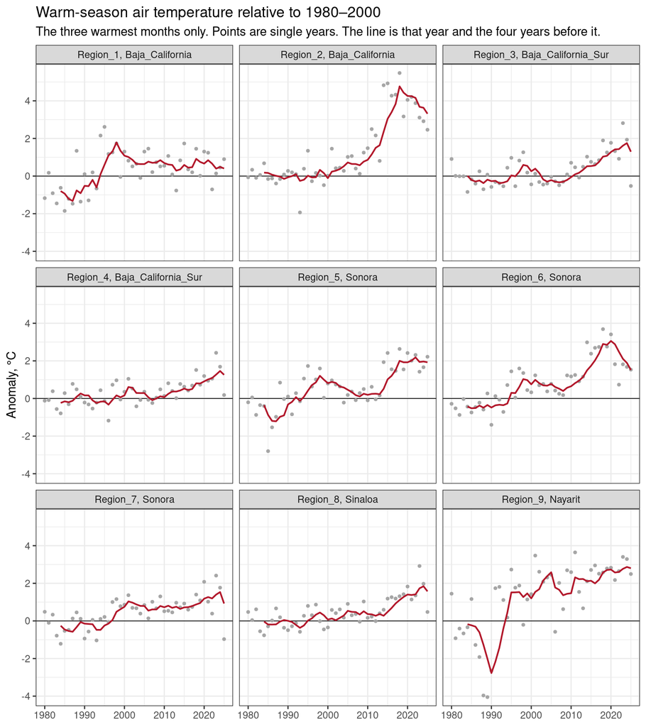

```r
ggplot(warm_region, aes(year)) +
  geom_hline(yintercept = 0, linewidth = 0.3) +
  geom_point(aes(y = anomaly_c), color = "grey65", size = 0.9) +
  geom_line(aes(y = roll5_c), color = "#b2182b", linewidth = 0.7) +
  facet_wrap(vars(paste(rgn_id, estado, sep = ", ")), ncol = 3) +
  labs(
    title = "Warm-season air temperature relative to 1980–2000",
    subtitle = "The three warmest months only. Points are single years. The line is that year and the four years before it.",
    x = NULL,
    y = "Anomaly, °C"
  ) +
  theme_bw()
```

```r
warm_cell <- year_month %>%
  filter(month %in% warm_months$month) %>%
  group_by(sample_id, year) %>%
  summarise(tmean = mean(tmean), .groups = "drop") %>%
  group_by(sample_id) %>%
  summarise(
    anomaly_2025 = mean(tmean[year >= 2021 & year <= 2025]) -
      mean(tmean[year >= 1980 & year <= 2000]),
    .groups = "drop"
  )

warm_sf <- sites %>%
  select(sample_id) %>%
  inner_join(warm_cell, by = "sample_id")
```

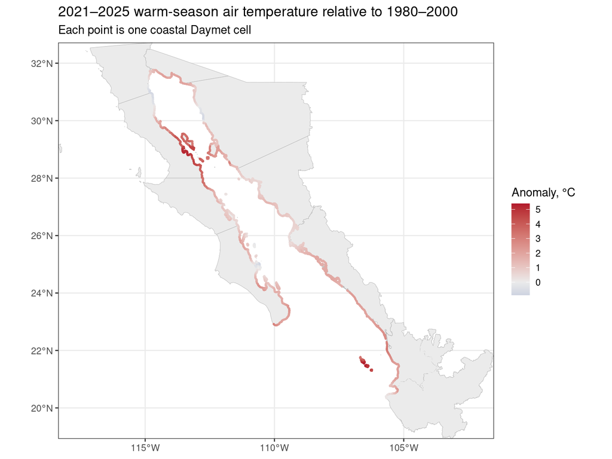

```r
ggplot() +
  geom_sf(data = land_outline, fill = "grey92", color = "grey70", linewidth = 0.15) +
  geom_sf(data = warm_sf, aes(color = anomaly_2025), size = 0.25) +
  scale_color_gradient2(
    low = "#2166ac",
    mid = "grey92",
    high = "#b2182b",
    midpoint = 0,
    name = "Anomaly, °C"
  ) +
  coord_sf(expand = FALSE) +
  labs(
    title = "2021–2025 warm-season air temperature relative to 1980–2000",
    subtitle = "Each point is one coastal Daymet cell"
  ) +
  theme_bw()
```

## 6. Pressure since 2000

The pressure for a year is the trailing five-year anomaly divided by 3°C, held between 0 and 1, and rounded to two decimal places. The full-year series and the three warmest months are saved separately. Both run from 2000 through 2025, so 2000 is the mean of 1996–2000 and 2025 is the mean of 2021–2025.

The spreadsheet keeps the reference climate, the single year 2025, and the 2021–2025 anomaly, once for the full year and once for July–September. The rasters are the cell version of the 2025 row: the raw 2021–2025 anomaly, and that anomaly divided by 3°C. They are written on Daymet’s 1 km Lambert grid. Where the shore bends, more than one sample can fall in the same pixel, and that pixel is their mean.

```r
pressure_score <- function(series) {
  series %>%
    filter(year >= 2000, year <= 2025) %>%
    transmute(
      rgn_id,
      year,
      pressure = round(pmin(pmax(roll5_c / reference_rise_c, 0), 1), 2)
    ) %>%
    arrange(rgn_id, year)
}

annual_pressure <- pressure_score(anomaly)
warm_pressure <- pressure_score(warm_region)

annual_pressure_path <- file.path(out_dir, "air_temp_annual_pressure.csv")
warm_pressure_path <- file.path(out_dir, "air_temp_warm_pressure.csv")
write_csv(
  annual_pressure %>% mutate(pressure = sprintf("%.2f", pressure)),
  annual_pressure_path
)
write_csv(
  warm_pressure %>% mutate(pressure = sprintf("%.2f", pressure)),
  warm_pressure_path
)

summary_table <- function(latest_rows) {
  latest_rows %>%
    transmute(
      Region = rgn_id,
      State = estado,
      Ecoregion = ecorgn,
      `1980–2000 mean, °C` = round(reference_c, 2),
      `2025 anomaly, °C` = round(anomaly_c, 2),
      `2021–2025 anomaly, °C` = round(roll5_c, 2)
    )
}

summary_path <- file.path(out_dir, "air_temp_summary.xlsx")
write_xlsx(
  list(
    full_year = summary_table(latest),
    warm_months = summary_table(warm_latest)
  ),
  summary_path
)

kable(
  annual_pressure %>%
    filter(year == 2025) %>%
    left_join(
      warm_pressure %>% filter(year == 2025) %>% select(rgn_id, warm = pressure),
      by = "rgn_id"
    ),
  digits = 2,
  col.names = c("Region", "Year", "Full-year pressure", "Warm-season pressure"),
  caption = "2025 pressure. The anomaly behind each score is 2021–2025 minus 1980–2000, divided by 3°C."
)
```

2025 pressure. The anomaly behind each score is 2021–2025 minus 1980–2000, divided by 3°C.

| Region | Year | Full-year pressure | Warm-season pressure |
| --- | --- | --- | --- |
| Region_1 | 2025 | 0.15 | 0.14 |
| Region_2 | 2025 | 0.96 | 1.00 |
| Region_3 | 2025 | 0.37 | 0.43 |
| Region_4 | 2025 | 0.51 | 0.42 |
| Region_5 | 2025 | 0.52 | 0.64 |
| Region_6 | 2025 | 0.51 | 0.51 |
| Region_7 | 2025 | 0.49 | 0.31 |
| Region_8 | 2025 | 0.36 | 0.52 |
| Region_9 | 2025 | 0.54 | 0.93 |

```r
# Daymet V4 Lambert conformal conic, in meters. The header coordinate is
# the shoreline sample on that grid, so nearby samples can share a 1 km pixel.
daymet_crs <- paste(
  "+proj=lcc +lat_0=42.5 +lon_0=-100 +lat_1=25 +lat_2=60",
  "+x_0=0 +y_0=0 +datum=WGS84 +units=m +no_defs"
)

cells_to_raster <- function(cells, field) {
  xy <- cells %>%
    transmute(cell_x, cell_y, value = .data[[field]]) %>%
    filter(is.finite(value))
  grid <- rast(
    xmin = min(xy$cell_x) - 500,
    xmax = max(xy$cell_x) + 500,
    ymin = min(xy$cell_y) - 500,
    ymax = max(xy$cell_y) + 500,
    resolution = 1000,
    crs = daymet_crs
  )
  pts <- vect(xy, geom = c("cell_x", "cell_y"), crs = daymet_crs)
  rasterize(pts, grid, field = "value", fun = "mean")
}

annual_cells_2025 <- annual_cell %>%
  group_by(sample_id, cell_x, cell_y) %>%
  summarise(
    anomaly_c = mean(tmean[year >= 2021 & year <= 2025]) -
      mean(tmean[year >= 1980 & year <= 2000]),
    .groups = "drop"
  ) %>%
  mutate(pressure = round(pmin(pmax(anomaly_c / reference_rise_c, 0), 1), 2))

warm_cells_2025 <- year_month %>%
  filter(month %in% warm_months$month) %>%
  group_by(sample_id, year) %>%
  summarise(tmean = mean(tmean), n_months = n(), .groups = "drop") %>%
  filter(n_months == 3) %>%
  group_by(sample_id) %>%
  summarise(
    anomaly_c = mean(tmean[year >= 2021 & year <= 2025]) -
      mean(tmean[year >= 1980 & year <= 2000]),
    .groups = "drop"
  ) %>%
  inner_join(
    annual_cell %>% distinct(sample_id, cell_x, cell_y),
    by = "sample_id"
  ) %>%
  mutate(pressure = round(pmin(pmax(anomaly_c / reference_rise_c, 0), 1), 2))

annual_anomaly_tif <- file.path(out_dir, "air_temp_annual_anomaly_2025.tif")
annual_pressure_tif <- file.path(out_dir, "air_temp_annual_pressure_2025.tif")
warm_anomaly_tif <- file.path(out_dir, "air_temp_warm_anomaly_2025.tif")
warm_pressure_tif <- file.path(out_dir, "air_temp_warm_pressure_2025.tif")

writeRaster(cells_to_raster(annual_cells_2025, "anomaly_c"), annual_anomaly_tif, overwrite = TRUE)
writeRaster(cells_to_raster(annual_cells_2025, "pressure"), annual_pressure_tif, overwrite = TRUE)
writeRaster(cells_to_raster(warm_cells_2025, "anomaly_c"), warm_anomaly_tif, overwrite = TRUE)
writeRaster(cells_to_raster(warm_cells_2025, "pressure"), warm_pressure_tif, overwrite = TRUE)
```

The full-year pressure is /home/frazier/ohi_goc_prep/_pressures/prs_air_temp/output/air_temp_annual_pressure.csv. The warm-season pressure is /home/frazier/ohi_goc_prep/_pressures/prs_air_temp/output/air_temp_warm_pressure.csv. The comparison spreadsheet is /home/frazier/ohi_goc_prep/_pressures/prs_air_temp/output/air_temp_summary.xlsx, with one sheet for the full year and one for July–September. The 2025 cell anomaly and cell pressure are /home/frazier/ohi_goc_prep/_pressures/prs_air_temp/output/air_temp_annual_anomaly_2025.tif, /home/frazier/ohi_goc_prep/_pressures/prs_air_temp/output/air_temp_annual_pressure_2025.tif, /home/frazier/ohi_goc_prep/_pressures/prs_air_temp/output/air_temp_warm_anomaly_2025.tif, and /home/frazier/ohi_goc_prep/_pressures/prs_air_temp/output/air_temp_warm_pressure_2025.tif.